# Reproducible Research: Peer Assessment 1

## Loading and preprocessing the data

1. Load the data (i.e. read.csv())

```r
filename <- "repdata%2Fdata%2Factivity.zip"

if (!file.exists(filename)){
        fileURL <- "https://d396qusza40orc.cloudfront.net/repdata%2Fdata%2Factivity.zip"
        download.file(fileURL, filename, method="libcurl")
}
if (!file.exists("activity.csv")) {
        unzip(filename)
}

if("activity.csv" %in% dir()){
        data <- read.csv("./activity.csv",header = TRUE)
}
```

2. Process/transform the data (if necessary) into a format suitable for your analysis

```r
        data$date <- as.Date(data$date , "%Y-%m-%d")
        data <- as.data.frame(data)
        tot.n.steps.perday <-aggregate(steps ~ date, data,  FUN = sum)
        colnames(tot.n.steps.perday) <- c("days" ,"steps")
```

## What is mean total number of steps taken per day?

1. Make a histogram of the total number of steps taken each day

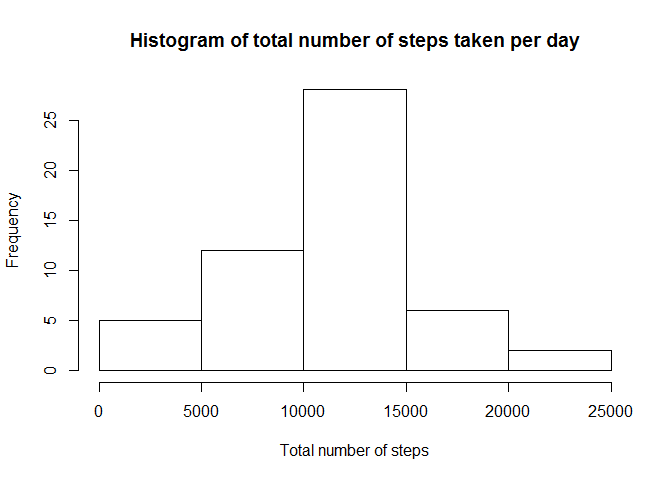

```r
hist(tot.n.steps.perday$steps, main = "Histogram of total number of steps taken per day", xlab = "Total number of steps")
```

2. Calculate and report the mean and median total number of steps taken per day

```r
print(paste("The mean of the total number of steps taken per day is ", mean(tot.n.steps.perday$steps),"and has a median of ", median(tot.n.steps.perday$steps)))
```

```
## [1] "The mean of the total number of steps taken per day is  10766.1886792453 and has a median of  10765"
```

## What is the average daily activity pattern?

1. Make a time series plot (i.e. type = “l”) of the 5-minute interval (x-axis) and the average number of steps taken, averaged across all days (y-axis)

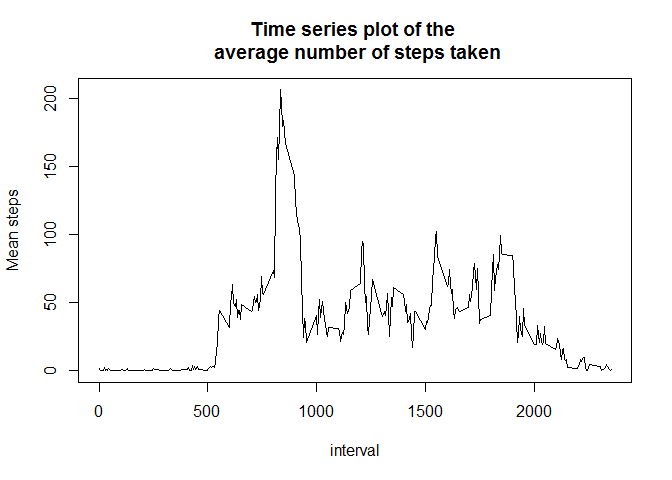

```r
Mean_steps <- aggregate(steps ~ interval, data, FUN = mean, na.rm = TRUE)
        colnames(Mean_steps) <- c("interval", "mean")

        plot(Mean_steps$interval, Mean_steps$mean, type = "l", main = "Time series plot of the \n average number of steps taken", xlab = "interval", ylab = "Mean steps")
```

2. Which 5-minute interval, on average across all the days in the dataset, contains the maximum number of steps?

```r
        maxsteps <- max(Mean_steps$mean)
        Maxinterval <- Mean_steps$interval[Mean_steps$mean == maxsteps]
        print(paste(Maxinterval," is the interval with maximum number of steps of ", maxsteps, " steps"))
```

```
## [1] "835  is the interval with maximum number of steps of  206.169811320755  steps"
```

## Imputing missing values

1. Calculate and report the total number of missing values in the dataset (i.e. the total number of rows with NAs)

```r
        missingdata <- sum(is.na(data$steps))
        print(paste("There are", missingdata, "missing data points."))
```

```
## [1] "There are 2304 missing data points."
```

2. Devise a strategy for filling in all of the missing values in the dataset. The strategy does not need to be sophisticated. For example, you could use the mean/median for that day, or the mean for that 5-minute interval, etc.

3. Create a new dataset that is equal to the original dataset but with the missing data filled in.

```r
        betterdata <- data
        betterdata$steps[is.na(betterdata$steps)] <- median(data$steps, na.rm=TRUE)
        betterdataday <- aggregate(steps ~ date, data=betterdata, sum, na.rm=TRUE)
```

4. Make a histogram of the total number of steps taken each day and Calculate and report the mean and median total number of steps taken per day. Do these values differ from the estimates from the first part of the assignment? What is the impact of imputing missing data on the estimates of the total daily number of steps?

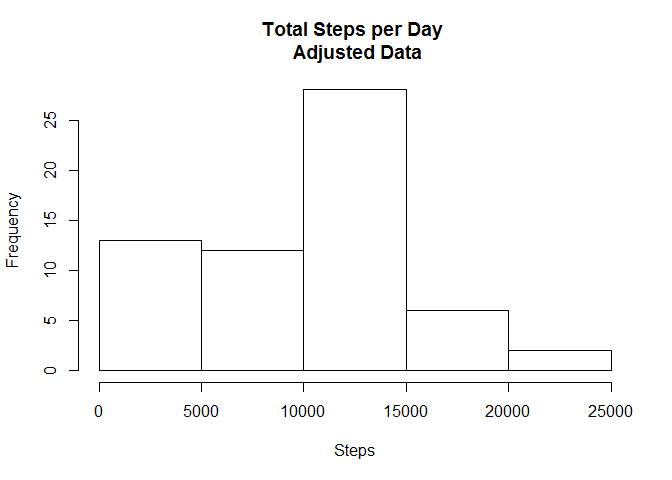

```r
        hist(betterdataday$steps, main="Total Steps per Day \n Adjusted Data",xlab="Steps", ylab="Frequency")
```

```r
        print(paste("The mean of the total number of steps taken per day after NA is replaced is ",mean(betterdataday$steps),"and has a median of ", median(betterdataday$steps)))
```

```
## [1] "The mean of the total number of steps taken per day after NA is replaced is  9354.22950819672 and has a median of  10395"
```

The mean and median has changed, and has made the histogram to skew

## Are there differences in activity patterns between weekdays and weekends?

1. Create a new factor variable in the dataset with two levels – “weekday” and “weekend” indicating whether a given date is a weekday or weekend day.

```r
        betterdata$date <- as.Date(betterdata$date)
        betterdata$dayname <- weekdays(betterdata$date)
        betterdata$weekend <- as.factor(ifelse(betterdata$dayname == "Saturday" |
                                                       betterdata$dayname == "Sunday", "weekend", "weekday"))
```

2. Make a panel plot containing a time series plot (i.e. type = “l”) of the 5-minute interval (x-axis) and the average number of steps taken, averaged across all weekday days or weekend days (y-axis). The plot should look something like the following, which was creating using simulated data:

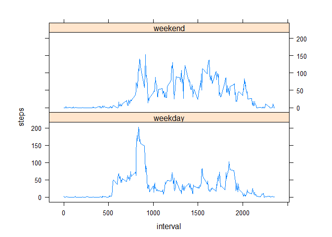

```r
        library(lattice)
        plotdata <- aggregate(steps ~ interval + weekend, betterdata, mean)
        xyplot(steps ~ interval | factor(weekend), data=plotdata, aspect=1/3, type="l")
```